# notebook

```
  ✓ numpy (déjà installé)
```

```
  ✓ pandas (déjà installé)
```

```
  ✓ matplotlib (déjà installé)
```

```
  ✓ seaborn (déjà installé)
  ✓ plotly (déjà installé)
  ✓ scipy (déjà installé)
```

```
  ✓ scikit-learn (déjà installé)
```

```
  ✓ kneed (déjà installé)

8 dépendances vérifiées.
```

Projet réalisé dans le cadre de la Situation d'Apprentissage et d'Evaluation - Data Mining par :

- Ibrahim BENKHERFELLAH
- Axel COULET
- Nathan RUELLE

# Phase 1 - Analyse Exploratoire des Données

## Analyse Exploratoire des Émissions Mondiales de Gaz à Effet de Serre

**Dataset :** Our World in Data (OWID) × EDGAR 2025  
**Période couverte :** 2013 - 2022  
**Thème :** Émissions de CO₂ et GES par pays, secteur et combustible

## 1. Présentation du Dataset

### 1.1 Origine et contexte

Ce dataset est issu de la fusion de deux sources institutionnelles de référence mondiale :

- **Our World in Data (OWID)** : organisation de recherche basée à l'Université d'Oxford, qui compile et publie des données agrégées sur les grands enjeux de développement. Les données CO₂ proviennent elles: mêmes de la **Global Carbon Project**, référence du GIEC pour les budgets carbone annuels.
- **EDGAR 2025** *(Emissions Database for Global Atmospheric Research)* - base de données de la Commission Européenne (JRC) fournissant les émissions détaillées par secteur pour le CO₂ fossile, le CH₄, le N₂O et les F-gaz.

Ces deux sources ont été fusionnées via une jointure sur `(country, year, iso_code)` après filtrage sur la période 2013-2022 et suppression des agrégats régionaux (absence d'`iso_code` → lignes supprimées automatiquement).

### 1.2 Structure du dataset

| Dimension | Valeur |
| --- | --- |
| Observations | 2 180 (218 pays × 10 ans) |
| Variables | 60 |
| Période | 2013 à 2022 |
| Granularité | Annuelle, par pays |

### 1.3 Catégories de variables

| Catégorie | Variables clés | Unité |
| --- | --- | --- |
| Macro | `co2`, `total_ghg`, `gdp`, `population`, `primary_energy_consumption` | t, t CO₂eq, USD, - , TWh |
| CO₂ par combustible | `CO2_Coal`, `CO2_Oil`, `CO2_Gas`, `CO2_Cement`, `CO2_Flaring` | t CO₂ |
| CO₂ par secteur | `CO2_Electricity and heat`, `CO2_Transport`, `CO2_Buildings`, `CO2_Industry`… | t CO₂ |
| CH₄ par secteur | `CH4_Agriculture`, `CH4_Fugitive emissions`… | t CO₂eq |
| N₂O par secteur | `N2O_Agriculture`, `N2O_Industry`… | t CO₂eq |
| F-gaz (EDGAR) | `FGASES_Industry` | t CO₂eq |
| Fossiles (EDGAR) | `FOSSIL_Energy`, `FOSSIL_Transport`, `FOSSIL_Industry`… | t CO₂eq |

## 2. Nettoyage des Données

Le pipeline de nettoyage réalise les opérations suivantes :

```
23:56:01  INFO      Chargement OWID initial…
```

```
23:56:01  INFO      Chargement EDGAR (4 feuilles)…
```

```
23:56:08  INFO        Fossil CO2 : 7910 lignes, 14 colonnes
```

```
23:56:11  INFO        CH4 AR5 : 7805 lignes, 14 colonnes
```

```
23:56:18  INFO        N2O AR5 : 7910 lignes, 15 colonnes
```

```
23:56:19  INFO        F-gases AR5 : 5460 lignes, 4 colonnes
```

```
23:56:19  INFO      Chargement OWID détaillé (6 fichiers)…
```

```
23:56:19  INFO      Préparation des DataFrames pour la jointure…
```

```
23:56:19  INFO      GC : 0 objets récupérés après préparation.
```

```
23:56:19  INFO      Jointure de 10 sources…
```

```
23:56:20  INFO      Fichier exporté → data\donnees_nettoyees.csv
```

```
Nombre de lignes base : 2180
Nombre de lignes final : 2180
```

```
Dimensions      : 2180 observations x 60 variables
Periode         : 2013 - 2022
Pays uniques    : 218
Annees          : [2013, 2014, 2015, 2016, 2017, 2018, 2019, 2020, 2021, 2022]

--- Apercu (5 premieres lignes, 8 premieres colonnes) ---
       country  year iso_code  population           gdp        co2  \
0  Afghanistan  2013      AFG  31622709.0  6.299370e+10  8891000.0
1  Afghanistan  2014      AFG  32792528.0  6.434611e+10  8698000.0
2  Afghanistan  2015      AFG  33831767.0  6.278339e+10  9384000.0
3  Afghanistan  2016      AFG  34700613.0  6.437222e+10  8606000.0
4  Afghanistan  2017      AFG  35688941.0  6.516928e+10  9311000.0

   primary_energy_consumption   total_ghg
0                  31869000.0  30170000.0
1                  26630000.0  30691000.0
2                  30954000.0  30707000.0
3                  28075000.0  29947000.0
4                  36517000.0  33678000.0
```

Les deux vérifications de cohérence ci-dessous confirment la qualité de la fusion.

```
=== DIAGNOSTIC GENERAL ===
Dimensions du dataset : 2180 observations x 60 variables
Période               : 2013 - 2022
Pays uniques          : 218
Années disponibles    : [2013, 2014, 2015, 2016, 2017, 2018, 2019, 2020, 2021, 2022]

=== VALEURS MANQUANTES ===
Aucune valeur manquante.

=== VARIABLES PEU INFORMATIVES ===
Seuil de conservation retenu : 45.09%

=== COHERENCE : Somme(CO2_combustibles) vs CO2 total ===
Ecart moyen (%)       : 0.35%
Ecart médian (%)      : 0.01%
Pays avec écart < 15% : 213 / 213

=== DATASET DE TRAVAIL ===
Dataset initial       : 2180 obs.
Dataset de travail    : 1640 obs.

=== FILTRAGE GLOBAL ===
Variables numériques avant filtrage : 60
Variables conservées                : 51
Variables supprimées                : 9

=== DATASET FINAL D'ANALYSE ===
Dimensions : 1640 observations x 54 colonnes
```

### Bilan du nettoyage

- **Aucune valeur manquante** : la convention OWID/EDGAR impute les données non rapportées à zéro, ce qui est cohérent avec l'interprétation "émissions nulles ou non renseignées".
- **Cohérence vérifiée** : l'écart entre la somme des émissions par combustible et le total `co2` est inférieur à 15 % pour la grande majorité des pays, reflétant les différences de périmètre entre les deux sources (OWID exclut certains types d'émissions fugitives mineurs).
- **Variables dérivées** créées pour l'analyse :
  - `co2_per_capita` = `co2 / population` (en t CO₂/habitant)
  - `gdp_per_capita` = `gdp / population` (en USD/habitant)
  - `ghg_non_co2` = `total_ghg − co2` (CH₄ + N₂O + F-gaz, en t CO₂eq) - variable indépendante de `co2`

## 3. Analyse en Dimension 1

### 3.1 Statistiques Descriptives

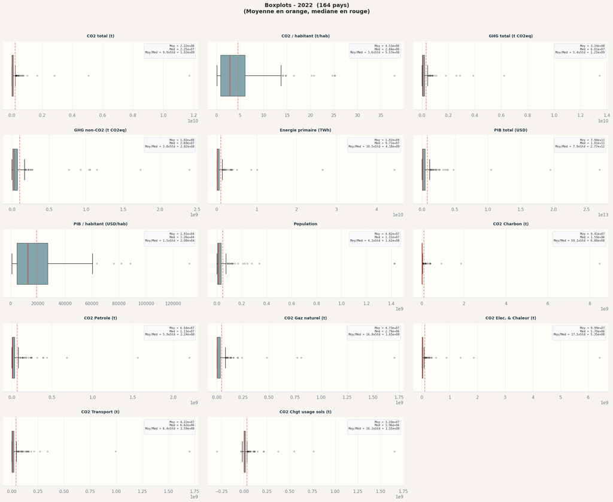

### Interprétation des Boxplots (avec outliers)

Les boxplots confirment la forte asymétrie des distributions déjà observée dans les histogrammes :

- **Variables absolues** (CO2 total, PIB, population, énergie) : les boîtes sont écrasées à gauche, avec de longs whiskers et de nombreux outliers à droite. Le ratio Moy/Med entre 4x et 17x reflète la domination de quelques pays géants (Chine, USA, Inde) qui tirent la moyenne loin de la médiane.
- **Variables per capita** (CO2/hab, PIB/hab) : l'asymétrie est nettement réduite (Moy/Med ≈ 1.5x), ce qui valide le choix de travailler en variables intensives pour la classification - elles neutralisent l'effet taille et rendent les pays comparables.
- **CO2 Charbon** : cas extrême avec Moy/Med ≈ 59x - la majorité des pays n'utilisent presque pas de charbon, mais quelques gros consommateurs (Chine, Inde) créent une queue de distribution massive.
- **CO2 Changement d'usage des sols** : seule variable présentant des valeurs négatives (pays absorbeurs nets grâce à la reforestation), ce qui en fait une variable particulièrement informative.

La présence systématique d'outliers rend la lecture des boîtes difficile sur plusieurs graphiques - les distributions étant compressées à gauche par les valeurs extrêmes. Pour mieux visualiser la structure centrale des données, nous reproduisons les mêmes boxplots en retirant les outliers (méthode IQR ×1.5).

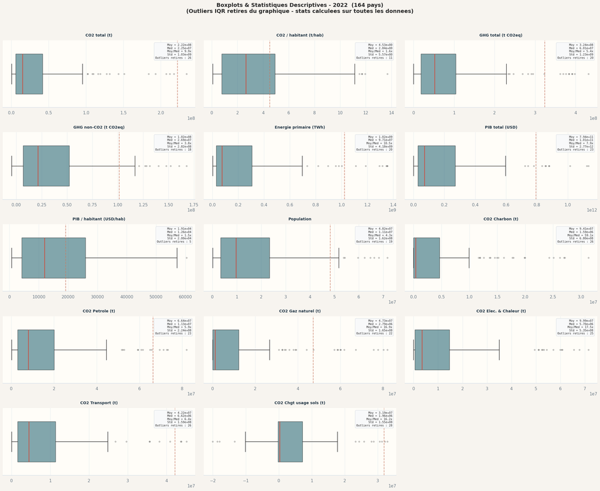

### Interprétation des Boxplots (sans outliers IQR)

En retirant les outliers par la méthode classique IQR ×1.5, la structure centrale des distributions devient lisible :

> Les statistiques affichées (moyenne, médiane, écart-type) restent calculées sur l'ensemble complet des données, seule la représentation graphique est filtrée pour améliorer la lisibilité.

> *Source : [Interquartile Range Method (IQR)](https://procogia.com/interquartile-range-method-for-reliable-data-analysis/)*

### 3.2 Distributions des Variables Clés (Zoom Q95)

Pour compléter l'analyse des boxplots, nous visualisons ici les distributions sous forme d'histogrammes en zoomant sur les 95% de la population. Ce zoom permet de mieux observer la forme des distributions sans être écrasé par les valeurs extrêmes, tout en conservant la moyenne et la médiane calculées sur l'ensemble des données.

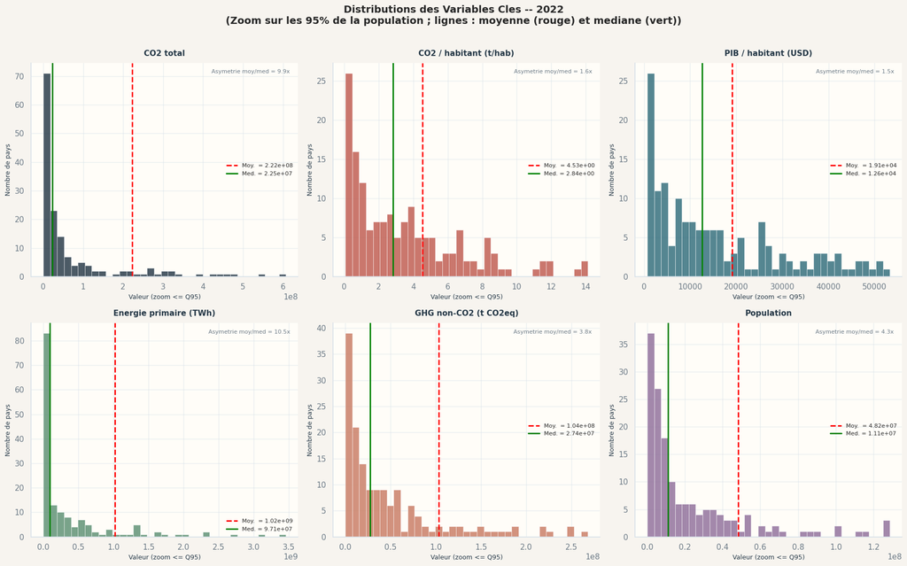

Les histogrammes confirment et affinent les observations des boxplots. Toutes les variables absolues (CO2 total, énergie, population) présentent une distribution fortement concentrée à gauche avec une longue queue droite - la majorité des pays émettent peu, consomment peu et sont de taille modeste. L'écart entre la moyenne (rouge) et la médiane (vert) illustre visuellement l'asymétrie : plus ces deux lignes sont éloignées, plus la distribution est tirée par quelques pays extrêmes.

Les variables `per capita` se distinguent nettement avec des distributions plus étalées et un ratio moy/méd de seulement 1.5x - signe que la normalisation par la population réduit considérablement l'effet de concentration et rend les pays plus comparables entre eux. Le GHG non-CO2 (moy/méd = 3.8x) occupe une position intermédiaire, reflétant le fait que le méthane agricole est plus uniformément réparti que les émissions fossiles.

### 3.3 Évolution de la Répartition des Émissions (2013 vs 2022)

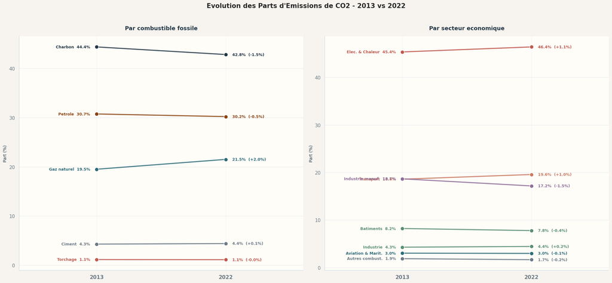

Le constat principal est l'inertie du système énergétique mondial : en dix ans, aucune part ne bouge de plus de 2 points. Le gaz naturel grignote du terrain au charbon côté combustibles, traduisant une transition lente vers des fossiles moins carbonés. Côté secteurs, l'électricité et chaleur renforce sa domination $\Rightarrow$ décarbonation de la production électrique reste le levier prioritaire pour réduire les émissions globales.

## 4. Analyse en Dimension 2

### 4.1 Matrices de Corrélation et Gestion de la Multicolinéarité

Avant d'étudier les relations entre variables, il faut traiter un problème fondamental : la **multicolinéarité**. Les variables brutes (CO2_Coal, CO2_Oil, CO2_Transport, etc.) sont des composantes additives du CO2 total - elles partagent mécaniquement la même variance de taille. Les corréler entre elles revient à mesurer à quel point "les gros pays sont gros", ce qui n'apprend rien.

**Pourquoi la log-transformation ?** La corrélation de Pearson mesure des relations linéaires, or nos variables brutes suivent des distributions exponentielles (quelques géants, beaucoup de petits pays). Le logarithme linéarise ces relations multiplicatives et rend Pearson pertinent. On l'applique aux variables de base (CO2, PIB, énergie) mais pas aux parts qui sont déjà bornées entre 0 et 1.

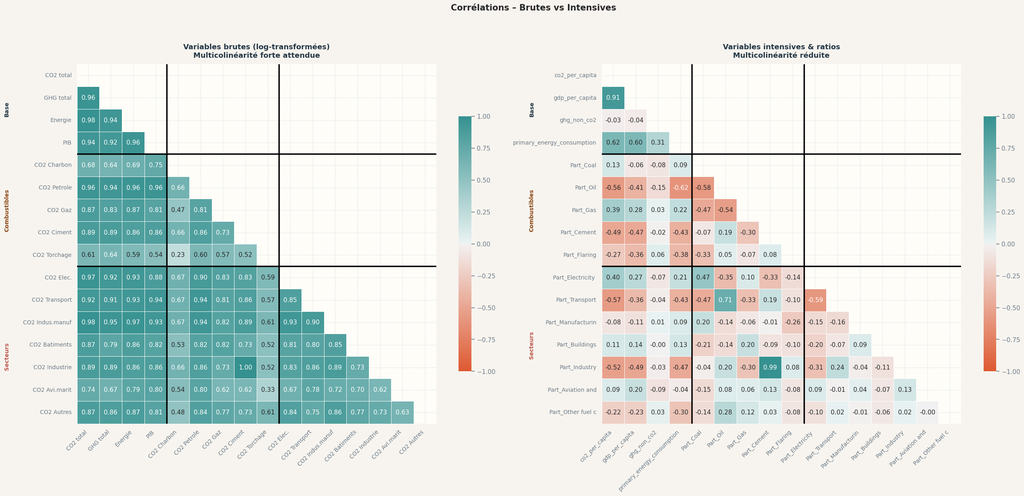

```
Corrélations avec CO2/hab (variables intensives, triées par |r|) :
  *** gdp_per_capita                  r = +0.907
  *** primary_energy_consumption      r = +0.615
  *** Part_Transport                  r = -0.565
  *** Part_Oil                        r = -0.564
  *** Part_Industry                   r = -0.524
  *** Part_Cement                     r = -0.487
  *** Part_Electricity                r = +0.397
  *** Part_Gas                        r = +0.387
      Part_Flaring                    r = -0.271
      Part_Other fuel c               r = -0.224
      Part_Coal                       r = +0.131
      Part_Buildings                  r = +0.112
      Part_Aviation and               r = +0.093
      Part_Manufacturin               r = -0.079
      ghg_non_co2                     r = -0.030
```

### Interprétation

La transformation en variables intensives a bien rempli son rôle : on passe d'une matrice dominée par un seul facteur (la taille) à une structure multidimensionnelle exploitable pour la régression et la classification en Phase 2.

### 4.2 Relations Bivariées Clés

Pour aller au-delà des coefficients de corrélation, nous visualisons trois paires de variables choisies pour leur intérêt analytique : une corrélation forte, une modérée, et une faible. La taille et la couleur des points reflètent le CO2 total du pays.

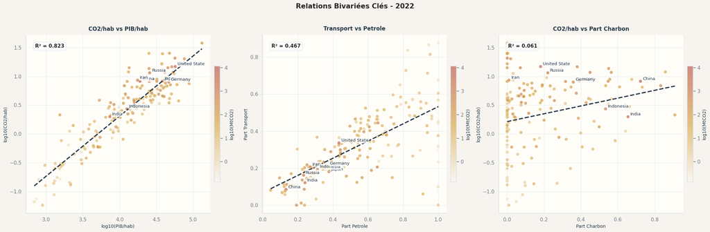

### Interprétation

Le log10(PIB/hab) domine largement l'explication du log10(CO2/hab) $\rightarrow$ le niveau de développement reste le premier déterminant des émissions par tête.

La relation pétrole-transport confirme une dépendance structurelle attendue mais imparfaite.

Le résultat le plus parlant est le troisième scatter : la part du charbon seule n'explique quasiment rien avec un paquet de pays à charbon quasi nul mais des niveaux d'émissions très variés. Cela suggère que ce n'est pas un combustible isolé qui détermine le profil d'émissions d'un pays, mais la combinaison de l'ensemble du mix - une intuition qui justifie le recours à la régression multiple et à l'ACP en Phase 2.

## 5. Classification en Dimension 2

### 5.1 Choix des variables et justification

**Variables retenues :** `log(CO2/habitant)` × `log(PIB/habitant)`

Ces deux variables sont issues de la transformation en variables intensives réalisée pour traiter la multicolinéarité (section 4.1). Elles neutralisent l'effet taille et captent deux dimensions complémentaires : la **pression climatique** (CO2/hab) et le **niveau de développement** (PIB/hab).

Leur corrélation (r = 0.91) est élevée mais acceptable dans le cadre d'une classification en dimension 2 - le scatter plot (section 4.2) montre une dispersion importante autour de la droite de tendance, signe que les deux variables ne sont pas redondantes. C'est précisément cette dispersion que la classification va exploiter : à PIB/hab égal, certains pays émettent bien plus que d'autres selon leur mix énergétique.

La log-transformation est appliquée avant standardisation pour linéariser les distributions asymétriques, comme justifié lors de l'analyse des corrélations. Ce couple de variables correspond à la représentation classique de la **courbe de Kuznets environnementale**, utilisée pour segmenter les pays selon leur trajectoire développement-émissions.

### 5.2 Recherche du nombre optimal de clusters - CAH

Les données sont maintenant standardisées sur les deux axes log-transformés. On attaque la classification par la CAH avec la méthode de Ward, une approche hiérarchique qui construit les groupes de bas en haut sans qu'on ait à fixer k à l'avance. La méthode du coude sur les distances de fusion va nous indiquer à quel saut il devient trop coûteux de continuer à fusionner.

```
Nombre optimal de clusters (CAH) : 4
```

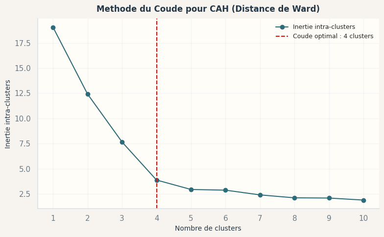

Le coude repère un saut dans les distances de fusion, mais c'est un signal indirect. Il ne montre pas la géographie réelle des regroupements. Le dendrogramme, lui, représente l'arbre de fusion complet et permet de confirmer visuellement si le nombre de clusters détecté correspond bien à une rupture structurelle dans les données.

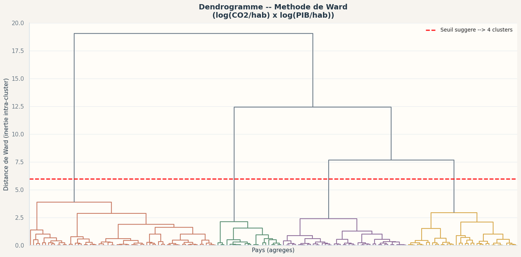

Le dendrogramme confirme une structure claire : au-delà du seuil en rouge, les branches se séparent en quatre groupes distincts avec des sauts de hauteur bien marqués entre les dernières fusions. Ce découpage est cohérent avec le signal du coude : on coupe l'arbre à 4 clusters et on projette maintenant chaque pays dans le plan CO2/PIB pour voir à quoi ressemble cette partition.

[interactive chart not shown]

Le nuage de points dessine une organisation géographiquement et économiquement cohérente : les pays riches à fortes émissions s'isolent dans un coin, les pays pauvres dans l'autre, avec des profils intermédiaires entre les deux. Les positions visuelles sont parlantes, mais pour donner un vrai sens à chaque groupe il faut calculer leurs caractéristiques moyennes et leur trouver un nom.

```
=== CARACTERISATION DETAILLEE DES CLUSTERS ===

Cluster 0 -- Pays développés (63 pays)
 - CO2 par habitant moyen : 9.26 t/hab
 - PIB par habitant moyen : 38110.35 USD/hab
 - Top 3 pays par CO2/habitant :
   * Qatar
   * Kuwait
   * Trinidad and Tobago

Cluster 1 -- Pays en développement (22 pays)
 - CO2 par habitant moyen : 0.19 t/hab
 - PIB par habitant moyen : 1395.23 USD/hab
 - Top 3 pays par CO2/habitant :
   * Gambia
   * Mali
   * Togo

Cluster 2 -- Pays en transition (42 pays)
 - CO2 par habitant moyen : 2.91 t/hab
 - PIB par habitant moyen : 12652.68 USD/hab
 - Top 3 pays par CO2/habitant :
   * Iraq
   * Barbados
   * Algeria

Cluster 3 -- Pays en difficulté (37 pays)
 - CO2 par habitant moyen : 0.89 t/hab
 - PIB par habitant moyen : 4786.89 USD/hab
 - Top 3 pays par CO2/habitant :
   * North Korea
   * Kyrgyzstan
   * Congo
```

### 5.3 Validation par K-Means

La CAH produit 4 groupes aux profils bien contrastés. Pour tester la robustesse de cette partition, on passe à K-Means : une méthode radicalement différente qui part des données brutes sans structure hiérarchique et minimise la variance interne des clusters. Si les deux méthodes convergent vers une organisation similaire, c'est un bon signal de stabilité de la structure sous-jacente.

```
Nombre optimal de clusters (K-Means) : 3
```

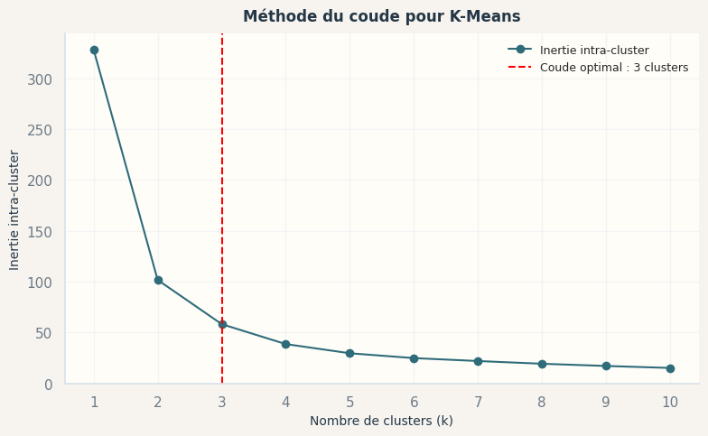

K-Means identifie un coude à trois clusters, un de moins que la CAH. Ce n'est pas un désaccord fondamental : K-Means est plus sensible à la compacité géométrique des groupes et peut en fusionner deux que la CAH distinguait pour d'autres raisons. Le scatter va montrer concrètement comment les frontières se sont repositionnées par rapport à la partition précédente.

[interactive chart not shown]

```
=== CARACTERISATION DETAILLEE DES CLUSTERS K-MEANS ===

Cluster 0 -- Pays en développement (32 pays)
 - CO2 par habitant moyen : 0.29 t/hab
 - PIB par habitant moyen : 1872.45 USD/hab
 - Top 3 pays par CO2/habitant :
   * Zimbabwe
   * Comoros
   * Nepal

Cluster 1 -- Pays développés (75 pays)
 - CO2 par habitant moyen : 8.40 t/hab
 - PIB par habitant moyen : 34708.33 USD/hab
 - Top 3 pays par CO2/habitant :
   * Qatar
   * Kuwait
   * Trinidad and Tobago

Cluster 2 -- Pays en transition (57 pays)
 - CO2 par habitant moyen : 1.81 t/hab
 - PIB par habitant moyen : 8370.73 USD/hab
 - Top 3 pays par CO2/habitant :
   * Equatorial Guinea
   * Venezuela
   * Ukraine
```

La clustering via K-Means a identifié 3 clusters optimaux, légèrement moins que les 4 clusters suggérés par la CAH. Les clusters K-Means présentent des caractéristiques similaires à ceux de la CAH, avec des groupes de pays développés, en développement et en transition. Cependant, la répartition des pays entre les clusters peut différer légèrement entre les deux méthodes, ce qui souligne l'importance de comparer les résultats et d'interpréter les clusters dans le contexte de l'analyse.

### 5.4 Comparaison des deux méthodes - Score de silhouette

On a maintenant deux partitions distinctes sur les mêmes données. Pour les départager objectivement, on calcule le score de silhouette $\rightarrow$ il mesure pour chaque pays à quel point il appartient clairement à son cluster plutôt qu'au cluster voisin, et donne un résumé global de la cohérence de chaque méthode.

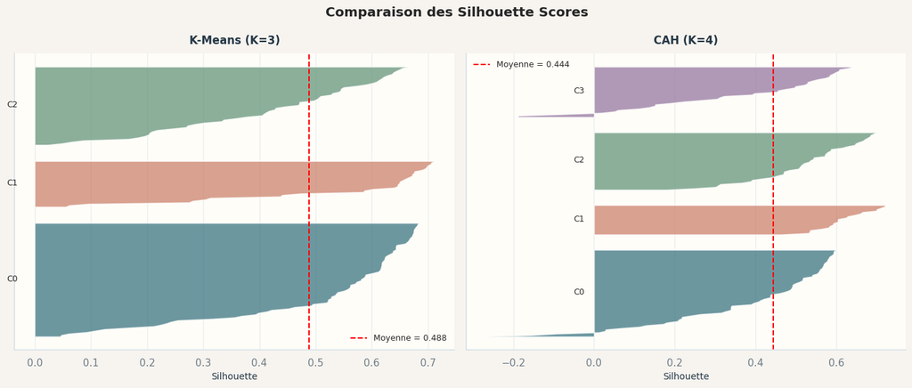

```
K-Means (K=3) : silhouette = 0.488
CAH (K=4) : silhouette = 0.444
```

K-Means obtient une silhouette légèrement meilleure que la CAH, ce qui confirme que sa partition est géométriquement plus compacte dans cet espace à deux dimensions. Pour autant, la CAH n'est pas éliminée : elle capture une nuance supplémentaire qui pourrait devenir pertinente dès qu'on enrichira l'espace avec les variables énergétiques. Ces deux lectures complémentaires serviront de base pour la suite de l'analyse.

## 6. Problématique

### Question centrale

> **Parmi les principaux déterminants (économiques, démographiques et industriels), lesquels d'entre eux expliquent le mieux l'évolution des émissions de CO₂ et du réchauffement climatique, et sur quels leviers prioritaires faut-il agir pour les réduire ?**

L'EDA a mis en évidence plusieurs éléments de réponse partiels. Le PIB/hab explique à lui seul 82% de la variance du CO2/hab (section 4.2), mais la dispersion autour de cette tendance montre que le niveau de richesse ne suffit pas : à PIB/hab comparable, certains pays émettent deux à trois fois plus que d'autres selon leur mix énergétique. Par ailleurs, la part du charbon prise isolément n'explique quasiment rien ($R^2$ = 0.06), ce qui suggère que c'est la **combinaison** des déterminants (et non un facteur unique) qui structure les profils d'émissions.

La classification en dimension 2 a permis de segmenter les pays en grands profils développement-émissions, mais elle reste limitée à deux variables. Elle ne capte ni la structure du mix énergétique, ni les GHG non-CO2 (méthane, N2O), ni les dynamiques sectorielles.

### Ce que nos analyses n'ont pas encore résolu

**Quels déterminants précisément ?** Le PIB/hab domine, mais quelle part de la variance revient au mix énergétique une fois l'effet richesse contrôlé ? → *Régression linéaire multiple (N > 2)*

**Quels profils en haute dimension ?** En intégrant simultanément les parts de combustibles, les secteurs, les GHG non-CO2 et les indicateurs économiques, quels groupes de pays émergent ? → *Classification N > 2*

**Quels leviers prioritaires ?** Quelles variables portent le plus d'inertie dans la structure des émissions mondiales ? → *ACP et cercle des corrélations*

### Hypothèse pour la Phase 2

La structure du mix énergétique (parts combustibles et sectorielles), combinée au PIB/habitant, constitue un meilleur prédicteur des émissions CO₂ per capita que les facteurs démographiques ou économiques seuls - une hypothèse testable par régression multiple et dont l'ACP permettra d'identifier les axes dominants.

# Phase 2 - Analyse des données en dimension n > 2

### 7.1 Variables retenues

On utilise des variables **intensives** (per capita, parts, ratios) pour neutraliser l'effet taille. Une ACP sur les variables brutes donnerait un premier axe trivial "gros pays vs petits pays" - sans intérêt pour notre problématique.

| Dimension | Variables |
| --- | --- |
| **Niveau** | CO2/hab, PIB/hab |
| **Mix fossile** | Parts charbon, pétrole, gaz, élec., transport, industrie |
| **GES non-CO2** | CH4 agri./hab, CH4 fugitif/hab, CH4 déchets/hab, N2O agri./hab, F-gaz indus./hab |
| **Efficacité** | Intensité énergétique, intensité carbone du PIB |

```
Individus : 164 pays | Variables : 15 | Année : 2022
```

### 7.2 Centrage-réduction, diagonalisation et vérifications

```
  ✓  Σλ_k = p            15.0000 = 15
```

La somme des valeurs propres est égale à 15, ce qui correspond exactement au nombre de variables actives utilisées dans l'ACP. C'est cohérent puisque les données ont été centrées-réduites : chaque variable contribue une variance unitaire de 1, et l'inertie totale du nuage est donc égale au nombre de variables.

### 7.3 Scree plot et choix des composantes

On cherche combien de composantes retenir. Sur la matrice de corrélation, chaque variable originale a une variance de 1 - donc une composante qui capte $\lambda_k < 1$ apporte moins qu'une seule variable d'origine. On retient les composantes avec $\lambda_k \geq 1$, complété par le seuil de 80% de variance cumulée.

```
Composante   λ_k  % variance  % cumulé
        C1 4.782      31.878    31.878
        C2 2.097      13.981    45.859
        C3 1.911      12.739    58.598
        C4 1.358       9.056    67.654
        C5 1.202       8.016    75.670
        C6 0.950       6.331    82.001
        C7 0.791       5.271    87.272
        C8 0.503       3.355    90.627
        C9 0.415       2.764    93.391
       C10 0.334       2.229    95.620
       C11 0.325       2.168    97.788
       C12 0.138       0.921    98.710
       C13 0.096       0.639    99.348
       C14 0.067       0.447    99.796
       C15 0.031       0.204   100.000

λ ≥ 1 : 5 composantes | 80% variance : 6 composantes
```

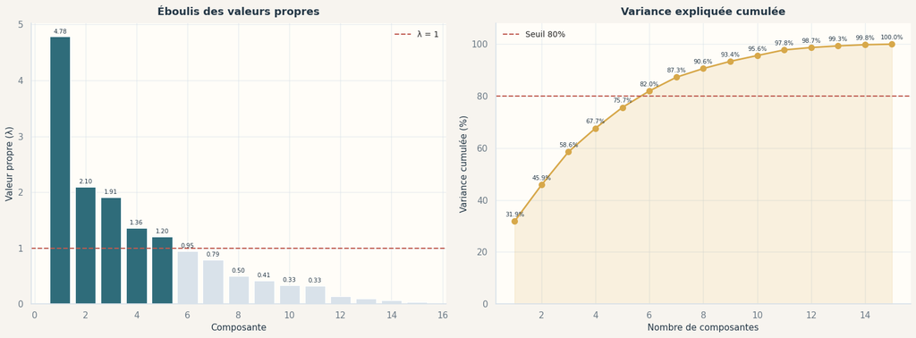

#### Interprétation

Le critère $\lambda \geq 1$ retient **5 composantes** (~76% d'inertie). Le seuil 80% est atteint à 6 composantes. C'est cohérent avec un jeu de 15 variables couvrant des dimensions très différentes - la variance est naturellement répartie.

### 7.4 Plan C1 × C2 - Individus et cercle des corrélations

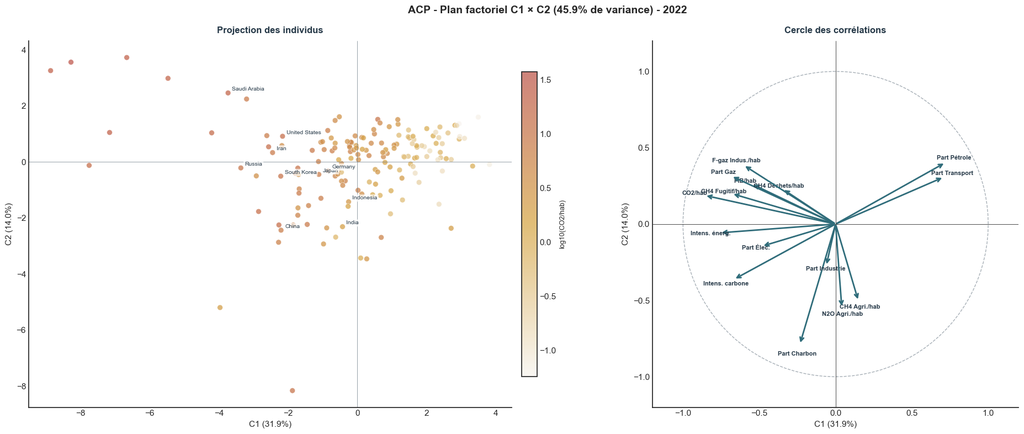

```
        Variable  cor(X, C1)  cor(X, C2)  Ctr C1 (%)  Ctr C2 (%)  cos²(C1)  cos²(C2)  cos²(C1+C2)
         CO2/hab      -0.856       0.187      15.317       1.674     0.732     0.035        0.768
    Part Pétrole       0.718       0.402      10.776       7.690     0.515     0.161        0.677
    Part Charbon      -0.234      -0.787       1.144      29.507     0.055     0.619        0.674
  Part Transport       0.707       0.307      10.456       4.489     0.500     0.094        0.594
  Intens. énerg.      -0.757      -0.057      11.980       0.157     0.573     0.003        0.576
 Intens. carbone      -0.665      -0.362       9.245       6.236     0.442     0.131        0.573
        Part Gaz      -0.681       0.313       9.700       4.673     0.464     0.098        0.562
F-gaz Indus./hab      -0.601       0.385       7.558       7.069     0.361     0.148        0.510
 CH4 Fugitif/hab      -0.678       0.199       9.621       1.882     0.460     0.039        0.500
         PIB/hab      -0.548       0.262       6.271       3.273     0.300     0.069        0.368
   N2O Agri./hab       0.041      -0.548       0.035      14.295     0.002     0.300        0.301
   CH4 Agri./hab       0.149      -0.502       0.464      12.019     0.022     0.252        0.274
      Part Élec.      -0.482      -0.145       4.855       1.002     0.232     0.021        0.253
 CH4 Déchets/hab      -0.346       0.229       2.500       2.499     0.120     0.052        0.172
  Part Industrie      -0.061      -0.272       0.078       3.534     0.004     0.074        0.078

Bien représentées (cos² ≥ 0.5) : 8 / 15
```

#### Interprétation C1 × C2

**Projection des individus** : les grands émetteurs fossiles (Arabie saoudite, USA, Russie) sont à gauche, les pays charbon (Inde, Chine) se distinguent vers le bas via C2, les pays sobres en carbone sont à droite. Le gradient de couleur confirme : teintes foncées (fort CO2/hab) à gauche, claires à droite.

### 7.5 Analyse 3D interactive - Projection et sphère des corrélations

[interactive chart not shown]

```
        Variable  Qualité 2D  Qualité 3D  Gain C3
   CH4 Agri./hab       0.274       0.924    0.649
   N2O Agri./hab       0.301       0.935    0.634
         PIB/hab       0.368       0.481    0.113
  Part Transport       0.594       0.689    0.095
    Part Charbon       0.674       0.768    0.094
         CO2/hab       0.768       0.854    0.086
      Part Élec.       0.253       0.306    0.053
  Part Industrie       0.078       0.123    0.045
 CH4 Fugitif/hab       0.500       0.542    0.042
F-gaz Indus./hab       0.510       0.549    0.040
    Part Pétrole       0.677       0.714    0.037
        Part Gaz       0.562       0.575    0.013
 Intens. carbone       0.573       0.581    0.009
 CH4 Déchets/hab       0.172       0.172    0.000
  Intens. énerg.       0.576       0.576    0.000

Gros gains avec C3 : CH4 Agri./hab, N2O Agri./hab, PIB/hab
```

#### Interprétation de C3

**Projection 3D** : l'ajout de C3 porte la variance expliquée à 58.6%. Le gradient de couleur reste cohérent avec le plan 2D - les grands émetteurs (foncés) sont toujours séparés des pays sobres (clairs) sur C1.

### 7.6 Contributions aux 5 axes retenus

```
        Variable  C1 (%)  C2 (%)  C3 (%)  C4 (%)  C5 (%)
         CO2/hab    15.3     1.7     4.5     2.0     0.3
  Intens. énerg.    12.0     0.2     0.0    16.6     2.0
    Part Pétrole    10.8     7.7     2.0     1.9     3.8
  Part Transport    10.5     4.5     5.0     2.5     0.0
        Part Gaz     9.7     4.7     0.7     0.1     3.2
 CH4 Fugitif/hab     9.6     1.9     2.2     9.9     0.9
 Intens. carbone     9.2     6.2     0.5    21.4     2.4
F-gaz Indus./hab     7.6     7.1     2.1     1.6     0.1
         PIB/hab     6.3     3.3     5.9    19.5     8.4
      Part Élec.     4.9     1.0     2.8    13.3    21.5
 CH4 Déchets/hab     2.5     2.5     0.0     0.3    22.0
    Part Charbon     1.1    29.5     4.9     6.2     0.2
   CH4 Agri./hab     0.5    12.0    34.0     0.1     0.2
  Part Industrie     0.1     3.5     2.4     4.5    34.4
   N2O Agri./hab     0.0    14.3    33.2     0.1     0.7
  Σ ctr C1 = 100.0%
  Σ ctr C2 = 100.0%
  Σ ctr C3 = 100.0%
  Σ ctr C4 = 100.0%
  Σ ctr C5 = 100.0%
```

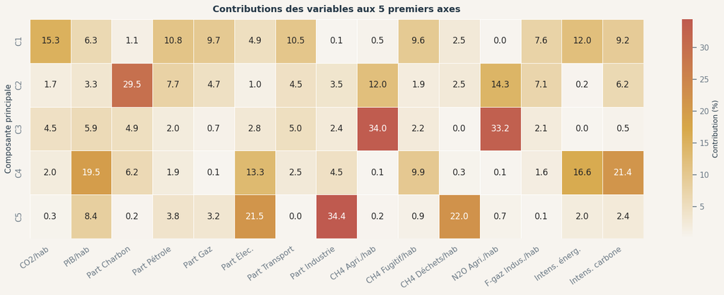

### 7.7 Synthèse

| Axe | % var. | Ce qu'il capte |
| --- | --- | --- |
| **C1** | ~32% | Intensité fossile globale (CO2/hab, pétrole, transport) |
| **C2** | ~14% | Charbon + émissions agricoles (CH4, N2O) |
| **C3** | ~13% | Dimension agricole pure (CH4 agri., N2O agri.) |
| **C4** | ~9% | Intensité carbone du PIB |
| **C5** | ~8% | Structure industrielle |

**Retour sur l'hypothèse de Phase 1 :** le PIB/hab n'est pas le premier facteur - c'est la dépendance globale aux fossiles qui domine. La part du charbon structure C2, pas C1. Et les émissions agricoles forment une dimension propre (C3), totalement indépendante du CO2 fossile.

**Variables redondantes :** Part Pétrole ≈ Part Transport (même direction sur C1).  
**Variables indépendantes :** CH4/N2O Agriculture apportent une info orthogonale au reste.

L'ACP confirme que 2 dimensions étaient insuffisantes : il faut 5 composantes pour capturer ~76% de la structure des émissions mondiales.

## 8. Régression linéaire multiple

### Rappel du modèle

$$y = X \hat{b} + \hat{\varepsilon}$$

L'estimateur des moindres carrés est :

$$\hat{b} = ({}^t\!X \, X)^{-1} \, {}^t\!X \, y$$

La variance des résidus :

$$\hat{\sigma}^2 = \frac{\|\hat{\varepsilon}\|^2}{n - p}$$

La matrice de variance-covariance de $\hat{b}$ :

$$\text{Var}(\hat{b}) = \hat{\sigma}^2 \, ({}^t\!X \, X)^{-1}$$

L'écart-type de chaque coefficient $\hat{b}_j$ se lit sur la diagonale :

$$\hat{\sigma}_{\hat{b}_j} = \hat{\sigma} \sqrt{[({}^t\!X \, X)^{-1}]_{jj}}$$

### 8.1 Corrélations bivariées avec la variable cible

Avant de construire un modèle multiple, on examine la corrélation de chaque variable explicative avec le CO2/hab pour identifier les meilleurs prédicteurs individuels.

```
        Variable       r     R²  p-value
         PIB/hab  0.7455 0.5558   0.0000
F-gaz Indus./hab  0.6853 0.4697   0.0000
 CH4 Fugitif/hab  0.6275 0.3937   0.0000
        Part Gaz  0.5619 0.3157   0.0000
  Intens. énerg.  0.5428 0.2946   0.0000
    Part Pétrole -0.4638 0.2151   0.0000
  Part Transport -0.4305 0.1853   0.0000
      Part Élec.  0.3290 0.1083   0.0000
 CH4 Déchets/hab  0.3142 0.0987   0.0000
    Part Charbon  0.0790 0.0062   0.3146
   N2O Agri./hab  0.0747 0.0056   0.3417
  Part Industrie -0.0469 0.0022   0.5512
   CH4 Agri./hab -0.0234 0.0005   0.7660
```

Les p-values confirment la significativité des corrélations : les 9 premières variables ont des p-values quasi nulles, ce qui signifie que leur corrélation avec le CO2/hab n'est pas due au hasard. En revanche, les dernières ont des p-values > 0.05 $\Rightarrow$ leur lien linéaire avec le CO2/hab n'est pas statistiquement significatif. Cela ne veut pas dire qu'elles sont inutiles, mais qu'elles n'expliquent pas le CO2/hab de manière isolée en dimension 2.

### 8.2 Nuages de points bivariés

On visualise chaque variable explicative contre le CO2/hab avec la droite de régression simple et le $R^2$.

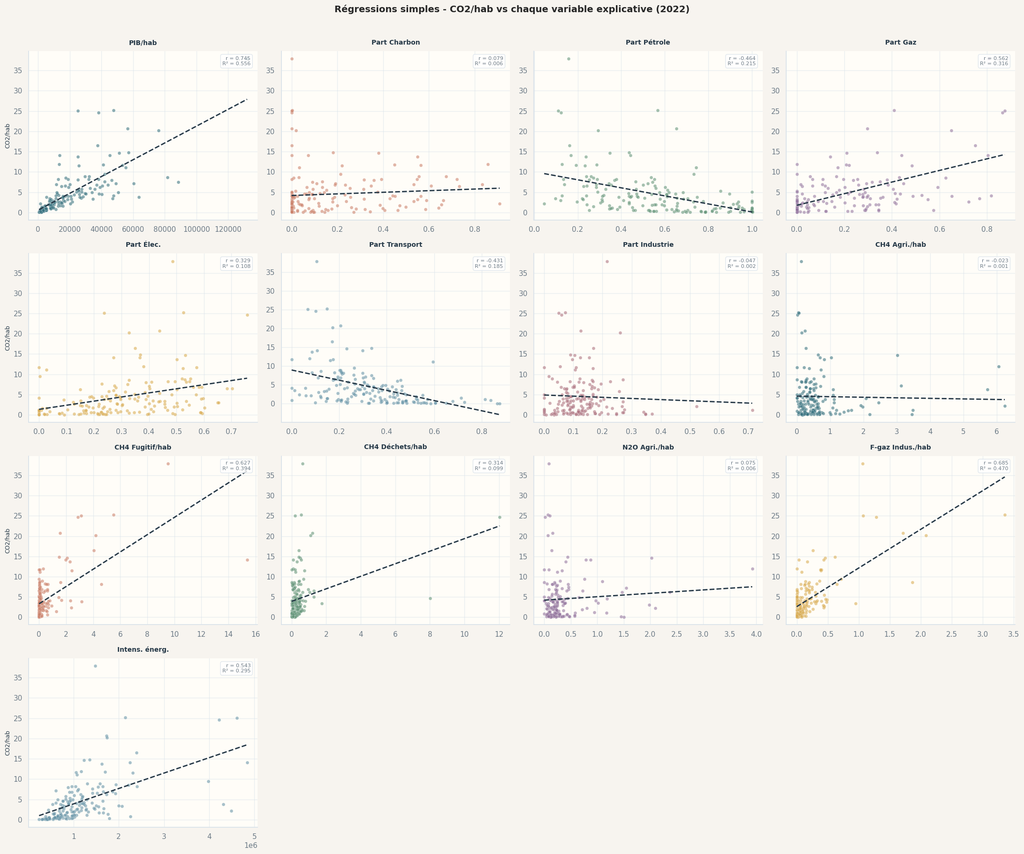

#### Interprétation des régressions simples

Les nuages de points montrent que la plupart des régressions simples s'ajustent mal : les points sont très dispersés autour de la droite ou bien très regroupés autour de l'origine, avec des $R^2$ souvent inférieurs à 0,30. Même le PIB/hab (meilleur prédicteur, $R^2$ ≈ 0.56) laisse près de la moitié de la variance inexpliquée.

Pour les variables comme Part Charbon, Part Industrie ou CH4 Agri./hab, la droite de régression est quasi horizontale $\Rightarrow$ elle n'explique rien. Cela confirme qu'aucune variable seule ne suffit à prédire le CO2/hab, et justifie le recours à la régression multiple en dimension N > 2.

### 8.3 Sélection du meilleur sous-ensemble de variables

Le $R^2$ classique a un défaut : il augmente **mécaniquement** à chaque variable ajoutée, même si elle n'apporte rien. Le $R^2$ ajusté corrige ce biais en pénalisant le nombre de variables $p$ :

$$R^2_{\text{adj}} = 1 - \frac{n - 1}{n - p - 1}(1 - R^2)$$

Le terme $\frac{n-1}{n-p-1}$ grossit avec $p$ : si une variable ajoutée n'améliore pas assez le $R^2$, le $R^2$ ajusté **baisse**. Cela permet de détecter le moment où empiler des variables ne sert plus à rien.

On teste toutes les combinaisons de 2 à 7 variables et on retient celle qui maximise ce critère.

> *Source : [DataCamp - R² ajusté](https://www.datacamp.com/fr/tutorial/adjusted-r-squared)*

```
p=2  R²=0.7373  R²adj=0.7340  →  PIB/hab, CH4 Fugitif/hab
```

```
p=3  R²=0.7943  R²adj=0.7904  →  PIB/hab, CH4 Fugitif/hab, F-gaz Indus./hab
```

```
p=4  R²=0.8232  R²adj=0.8188  →  PIB/hab, CH4 Fugitif/hab, F-gaz Indus./hab, Intens. énerg.
```

```
p=5  R²=0.8432  R²adj=0.8382  →  PIB/hab, Part Charbon, CH4 Fugitif/hab, CH4 Déchets/hab, F-gaz Indus./hab
```

```
p=6  R²=0.8515  R²adj=0.8458  →  PIB/hab, Part Charbon, CH4 Fugitif/hab, CH4 Déchets/hab, F-gaz Indus./hab, Intens. énerg.
```

```
p=7  R²=0.8586  R²adj=0.8522  →  PIB/hab, Part Charbon, Part Gaz, Part Industrie, CH4 Fugitif/hab, CH4 Déchets/hab, F-gaz Indus./hab
```

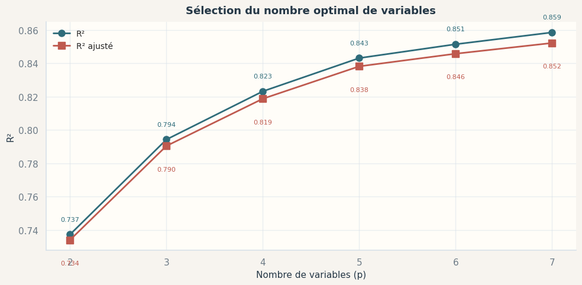

### 8.4 Modèle retenu - Estimation et inférence

On estime le vecteur des coefficients :

$$\hat{m} = ({}^t\!X \, X)^{-1} \, {}^t\!X \, y = \begin{pmatrix} \hat{a} \\ \hat{b}_1 \\ \vdots \\ \hat{b}_p \end{pmatrix}$$

La matrice de variance-covariance de $\hat{m}$ est :

$$\text{Var}(\hat{m}) = \hat{\sigma}^2 \, ({}^t\!X \, X)^{-1}$$

C'est une matrice $p \times p$ dont l'élément diagonal $[\text{Var}(\hat{m})]_{jj}$ donne la variance de $\hat{b}_j$. L'écart-type de chaque coefficient se lit donc :

$$\hat{\sigma}_{\hat{b}_j} = \hat{\sigma} \sqrt{[({}^t\!X \, X)^{-1}]_{jj}}$$

```
=== Modèle retenu : 6 variables ===
R²        = 0.8515
R² ajusté = 0.8458
σ̂²        = 4.7870
σ̂         = 2.1879
F(6, 157)  = 150.00,  p = 1.11e-16

        Variable      b̂  σ̂(b̂)       t  p-value signif.
     (constante) -1.2023  0.3613 -3.3282   0.0011      **
         PIB/hab  0.0001  0.0000 13.1864   0.0000     ***
    Part Charbon  3.4562  0.8224  4.2025   0.0000     ***
 CH4 Fugitif/hab  1.1059  0.1351  8.1869   0.0000     ***
 CH4 Déchets/hab  0.6670  0.1639  4.0693   0.0001     ***
F-gaz Indus./hab  3.4361  0.5441  6.3154   0.0000     ***
  Intens. énerg.  0.0000  0.0000  2.9615   0.0035      **
```

#### Interprétation des coefficients

Tous les coefficients sont **significatifs** (p < 0.01). Le modèle à 6 variables explique **~85%** de la variance du CO2/hab soit un gain de ~30% par rapport au PIB/hab seul. La **combinaison** des déterminants est bien plus puissante que n'importe quel facteur isolé !

### 8.5 Comparaison simple vs multiple - Nuages observé vs prédit

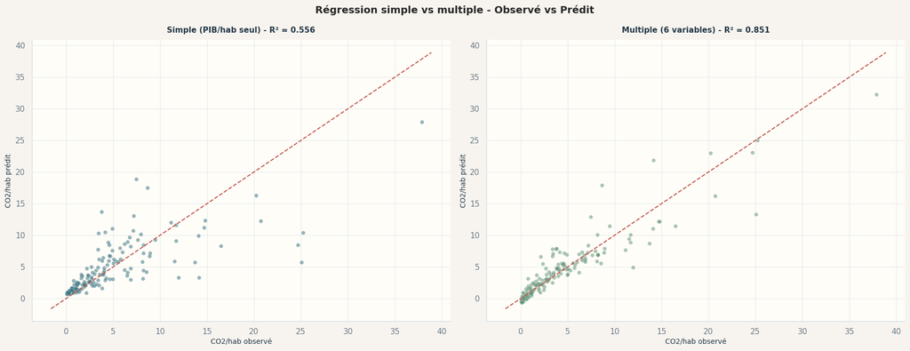

```
Gain de R² : 0.556 → 0.851 (+29.6 %)
```

Le passage de la régression simple à la régression multiple améliore nettement la qualité de prédiction. Visuellement, les points se resserrent autour de la diagonale rouge (prédiction parfaite) : à gauche, le nuage est très dispersé avec de nombreux pays mal prédits ; à droite, les points collent beaucoup mieux à la droite y = x. Le modèle multiple explique 85% de la variance du CO2/hab, contre 56% avec le PIB/hab seul $\rightarrow$ les 6 variables combinées captent donc une information que le PIB/hab seul ne pouvait pas fournir.

### 8.6 Diagnostic des résidus

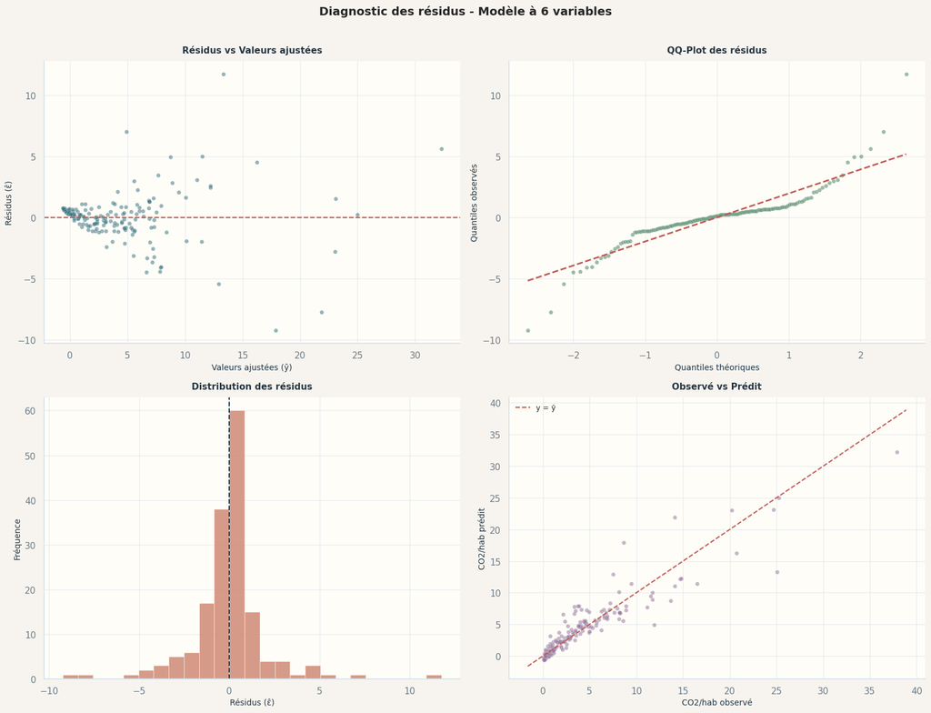

```
Shapiro-Wilk : W = 0.8371, p = 0.0000
Durbin-Watson : d = 2.0685
```

#### Interprétation des diagnostics

Le test de Shapiro-Wilk rejette formellement la normalité ce qui est logique avec n = 164. De plus, le test est très sensible aux quelques pays extrêmes visibles dans les queues du QQ-plot. En pratique, le coeur de la distribution est bien centré sur zéro, l'histogramme est approximativement symétrique, et le Durbin-Watson ≈ 2 confirme l'indépendance des résidus. Le modèle respecte donc raisonnablement les hypothèses de la régression linéaire.

### 8.7 Tube de confiance à 95%

Quand le modèle prédit $\hat{y}_i$ pour un pays, cette prédiction est incertaine. On distingue deux types d'incertitude :

**Intervalle de confiance (IC)** : où se situe la *vraie moyenne* au risque de 5% ?

$$\bar{\hat{y}}_i \pm t_{\alpha/2, \, n-p} \cdot \hat{\sigma} \sqrt{x_i^{\,t} ({}^t\!X \, X)^{-1} x_i}$$

Le terme $x_i^{\,t} ({}^t\!X \, X)^{-1} x_i$ mesure à quel point le pays $i$ est "loin" du centre du nuage - plus il est atypique, plus l'incertitude est grande.

**Intervalle de prédiction (IP)** : où se situe la *prédiction individuelle* au risque de 5% ? $$\hat{y}_i \pm t_{\alpha/2, \, n-p} \cdot \hat{\sigma} \sqrt{1 + x_i^{\,t} ({}^t\!X \, X)^{-1} x_i}$$

Le **+1** sous la racine est la clé. Dans l'IC, on n'a que le terme $x_i^t (X^tX)^{-1} x_i$ qui est l'incertitude sur la **moyenne estimée**, autrement dit : est-ce que la droite passe au bon endroit pour ce $x_i$ ?

Mais quand on prédit un **pays réel**, il faut ajouter son résidu individuel $\varepsilon_i$. Ce résidu a une variance de $\hat{\sigma}^2$, indépendante de l'incertitude sur le modèle. La variance totale devient donc :

$$\text{Var}(\text{prédiction}) = \underbrace{\hat{\sigma}^2 \cdot x_i^t(X^tX)^{-1}x_i}_{\text{incertitude sur la moyenne}} + \underbrace{\hat{\sigma}^2}_{\text{variabilité individuelle}}$$

En factorisant par $\hat{\sigma}^2$ :

$$= \hat{\sigma}^2 \left( x_i^t(X^tX)^{-1}x_i + 1 \right)$$

Conséquence : même avec un modèle parfaitement estimé (incertitude sur les coefficients $\rightarrow$ 0), l'IP ne descend jamais en dessous de $\pm t \cdot \hat{\sigma}$. C'est un **plancher incompressible** lié à la dispersion naturelle des pays autour de la tendance.

L'IP est donc toujours plus large que l'IC. C'est le même esprit que l'intervalle de fluctuation vu pour les proportions, mais appliqué ici à une variable continue.

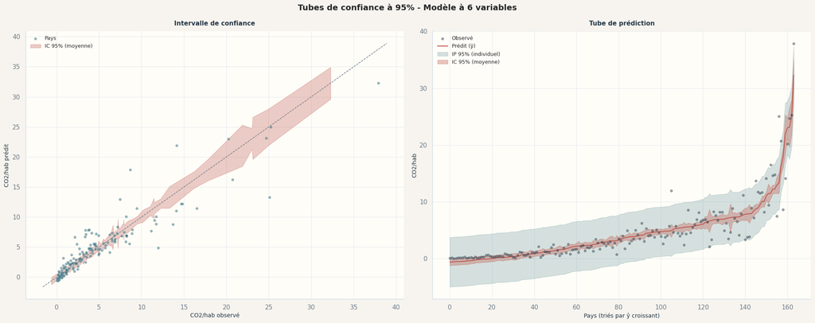

```
Couverture IC 95% : 39.6% des pays
Couverture IP 95% : 95.1% des pays
```

#### Interprétation

- Le **tube de confiance** (rouge) est étroit : le modèle est assez précis sur l'estimation de la moyenne
- Le **tube de prédiction** (bleu) est plus large : la variabilité individuelle reste importante - certains pays s'écartent de leur profil prédit
- La couverture de l'IP est proche de 95% comme attendu $\Rightarrow$ le modèle est bien calibré

### Équation du modèle final

$$\hat{y} = \hat{a} + \hat{b}_1 x_1 + \hat{b}_2 x_2 + \hat{b}_3 x_3 + \hat{b}_4 x_4 + \hat{b}_5 x_5 + \hat{b}_6 x_6$$

avec :

- $\hat{y}$ : CO2 par habitant (t/hab)
- $x_1$ : PIB par habitant (USD/hab)
- $x_2$ : Part du charbon dans le CO2 total
- $x_3$ : CH4 fugitif par habitant (t CO2eq/hab)
- $x_4$ : CH4 déchets par habitant (t CO2eq/hab)
- $x_5$ : F-gaz industriels par habitant (t CO2eq/hab)
- $x_6$ : Intensité énergétique (TWh / Mrd$)

```
ŷ = -1.2023
    + 0.0001 × PIB/hab
    + 3.4562 × Part Charbon
    + 1.1059 × CH4 Fugitif/hab
    + 0.6670 × CH4 Déchets/hab
    + 3.4361 × F-gaz Indus./hab
    + 0.0000 × Intens. énerg.
```

### 8.8 Synthèse de la régression

Le passage de la régression simple ($R^2 = 0.56$) à la régression multiple à 6 variables ($R^2 = 0.85$) fait passer le pouvoir explicatif de 56% à 85% de la variance du CO2/hab. Les variables retenues au-delà du PIB/hab :

- **Part du charbon** : dépendance au charbon → émissions plus élevées à PIB comparable
- **CH4 fugitif/hab** : proxy de l'activité extractive (fuites de méthane)
- **CH4 déchets/hab** : traitement des déchets
- **F-gaz industriels/hab** : marqueur d'industrialisation avancée
- **Intensité énergétique** : consommation d'énergie par unité de PIB

Le niveau de richesse seul est insuffisant $\rightarrow$ c'est la **structure énergétique et industrielle** qui fait la différence entre pays à PIB/hab comparable. C'est cohérent avec l'ACP où C1 (dépendance fossile) dominait devant le PIB/hab.

## 9. Classification en dimension N > 2

### Objectif

En Phase 1, la classification se limitait à 2 variables (log CO2/hab × log PIB/hab). On passe maintenant aux **15 variables intensives** utilisées dans l'ACP pour capturer la structure complète des profils d'émissions : mix fossile, GES non-CO2, intensités économiques.

On utilise les mêmes méthodes qu'en Phase 1 (CAH Ward + K-Means) mais sur les données standardisées en dimension 15.

### 9.1 Standardisation

Les variables sont centrées-réduites (même matrice $X$ que pour l'ACP) pour que chacune pèse le même poids dans le calcul des distances euclidiennes.

```
Individus : 164 | Variables : 15
```

### 9.2 CAH - Coude et dendrogramme

On applique la méthode de Ward et on cherche le nombre optimal de clusters via le coude des distances de fusion et le dendrogramme.

```
Nombre optimal de clusters (CAH) : 4
```

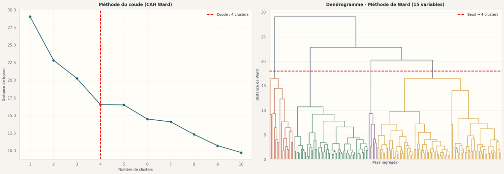

### 9.3 Visualisation CAH - Projection ACP

Dans notre cas, la classification est réalisée dans un espace de dimension élevée, ce qui ne permet pas une visualisation directe. Nous projetons donc les données sur les premières composantes principales issues de l’ACP précedente, afin d’obtenir une représentation en 2D et 3D.

Ce choix n’est pas arbitraire, car ces composantes maximisent la variance et capturent ainsi l’essentiel de l’information des données. Cela permet de visualiser les clusters de manière pertinente, même si cette projection reste une approximation de la structure réelle.

D’autres méthodes de réduction de dimension (comme t-SNE ou UMAP) existent et pourraient être utilisées, mais elles n’ont pas été abordées en cours ; nous avons donc choisi de ne pas les utiliser ici.

[interactive chart not shown]

La CAH identifie 4 groupes : un gros cluster central (88 pays), un cluster intermédiaire (53), et deux petits groupes atypiques - le cluster 0 (pays pétroliers, isolés à gauche sur C1) et le cluster 2 (pays agricoles, tirés vers le bas sur C2 par la Mongolie et l'Uruguay).

### 9.4 K-Means - Coude

```
Nombre optimal de clusters (K-Means) : 4
```

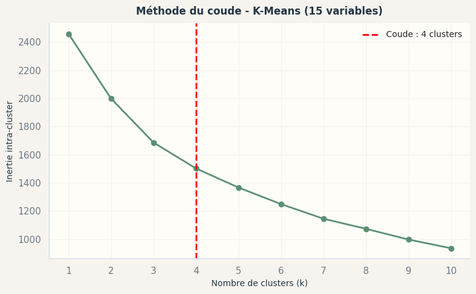

### 9.5 Visualisation K-Means - Projection ACP

[interactive chart not shown]

K-Means produit une partition plus équilibrée : deux gros clusters (72 et 74 pays) au centre, et deux petits groupes bien séparés - le cluster 2 (pays pétroliers/gaziers, à gauche sur C1) et le cluster 3 (pays agro-exportateurs, tirés vers le bas sur C2). Les centroïdes sont bien espacés, confirmant des profils distincts.

### 9.6 Comparaison - Silhouette

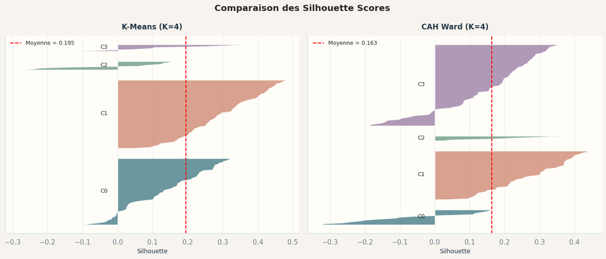

```
K-Means (K=4) : silhouette = 0.195
CAH Ward (K=4) : silhouette = 0.163
```

#### Interprétation des silhouettes

K-Means obtient une silhouette moyenne légèrement supérieure à celle de la CAH, ce qui indique des clusters géométriquement mieux délimités. On remarque cependant que les deux méthodes produisent des scores modestes. Cela est attendu en dimension 15 où les frontières entre profils de pays sont progressives plutôt que tranchées.

### 9.7 Caractérisation des clusters

```
           N pays  CO2/hab   PIB/hab  Part Charbon  Part Pétrole  Part Gaz  Part Élec.  Part Transport  Part Industrie  CH4 Agri./hab  CH4 Fugitif/hab  CH4 Déchets/hab  N2O Agri./hab  F-gaz Indus./hab  Intens. énerg.  Intens. carbone
Cluster
Cluster 0      72    5.212 23263.068         0.300         0.369     0.259       0.390           0.217           0.139          0.413            0.432            0.329          0.286             0.203     1324430.842       280093.229
Cluster 1      74    1.675 10932.183         0.062         0.765     0.083       0.226           0.448           0.123          0.554            0.069            0.304          0.280             0.072      809098.349       169259.363
Cluster 2      10   19.643 44485.829         0.003         0.327     0.607       0.404           0.153           0.129          0.334            5.388            1.703          0.194             1.178     2986390.466       594637.654
Cluster 3       8    5.815 26424.159         0.259         0.583     0.090       0.295           0.385           0.098          4.196            0.329            0.227          2.068             0.155      843332.948       249392.455

  Cluster 0 - Top 5 émetteurs : China, United States, India, Russia, Japan
  Cluster 1 - Top 5 émetteurs : Brazil, France, Spain, Nigeria, Colombia
  Cluster 2 - Top 5 émetteurs : Saudi Arabia, United Arab Emirates, Kuwait, Qatar, Venezuela
  Cluster 3 - Top 5 émetteurs : Australia, Mongolia, Ireland, New Zealand, Paraguay
```

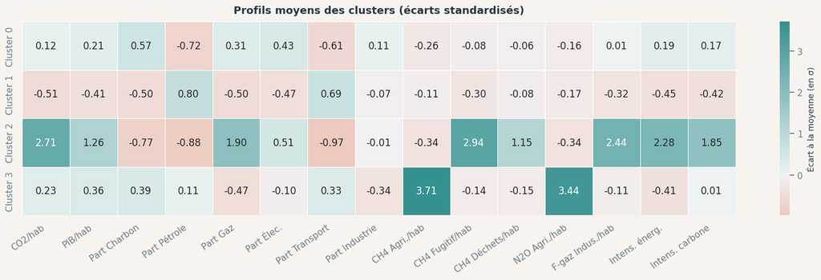

#### Lecture de la heatmap

Chaque case indique de combien d'écarts-types le cluster s'éloigne de la moyenne mondiale sur cette variable. Les profils sont clairs :

- **Cluster 0** : pays industrialisés à mix charbon/gaz/élec élevé, faible transport $\rightarrow$ **profil "usine du monde" (Chine, Inde, Russie)**
- **Cluster 1** : émissions basses sur toute la ligne, seule la part pétrole/transport ressort $\rightarrow$ **pays en développement ou économies de services (Brésil, France, Nigéria)**
- **Cluster 2** : valeurs extrêmes sur CO2/hab, gaz, CH4 fugitif, intensité énergétique $\rightarrow$ **pays pétroliers/gaziers du Golfe**
- **Cluster 3** : CH4 agri. et N2O agri. explosent (+3.7σ et +3.4σ), le reste est proche de la moyenne $\rightarrow$ **pays agro-exportateurs (Australie, Nouvelle-Zélande, Uruguay)**

C'est le cluster 3 qui est le plus intéressant : invisible en classification 2D (Phase 1), il n'émerge qu'en intégrant les émissions non-CO2 détaillées.

### 9.8 Projection 3D interactive

Pour avoir une meilleure visualisaion du clustering fait via K-MEANS (légrement meilleur que CAH), on projète cette fois ci sur les trois premières composantes.

[interactive chart not shown]

#### Interprétation

Comme nous pouvons le voir, en effet, en trois dimensions, on distingue nettement mieux les clusters, **car la projection selon trois composantes principales permet de réduire les chevauchements observés en 2D et de mieux capturer la structure intrinsèque des données**. On observe ainsi une séparation plus claire entre certains groupes, même si quelques points restent proches ou partiellement superposés, ce qui suggère des similarités entre ces observations ou une variance non totalement expliquée par ces trois composantes.

### 9.9 Synthèse de la classification N > 2

La classification en 15 dimensions identifie **4 profils de pays** plus nuancés qu'en Phase 1 :

[output not shown]

**Apport par rapport à la Phase 1 :** la classification 2D (CO2/hab × PIB/hab) ne distinguait pas les pays agricoles des pays fossiles. En intégrant les 15 variables, on voit émerger un **cluster agricole** (cluster 3) totalement invisible en 2D - ce sont des pays à CO2/hab modéré mais à très fortes émissions de méthane et de N2O. C'est cohérent avec l'axe C3 de l'ACP qui isolait cette dimension.

La CAH et le K-Means produisent des partitions proches, ce qui confirme la robustesse de la structure identifiée.

## 10. Conclusion générale

### Retour sur la problématique

La question centrale était : **quels déterminants expliquent le mieux les émissions de CO2 par habitant, et sur quels leviers agir ?** L'hypothèse de Phase 1 supposait que le mix énergétique combiné au PIB/hab serait le meilleur prédicteur. Nos trois analyses de Phase 2 permettent d'y répondre.

### Ce que chaque analyse a apporté

**L'ACP** a révélé que la structure des émissions mondiales ne se résume pas à un ou deux facteurs. Il faut **5 dimensions** pour capturer 76% de l'information : l'intensité fossile (C1, 32%), le type de combustible (C2, 14%), les émissions agricoles (C3, 13%), l'efficacité économique (C4) et la structure industrielle (C5). Le PIB/hab, que la Phase 1 plaçait au centre, se retrouve diffus sur plusieurs axes $\Rightarrow$ ce n'est pas **le** facteur structurant, c'est **un** facteur parmi d'autres.

**La régression multiple** confirme ce résultat quantitativement : le PIB/hab seul explique 56% du CO2/hab, mais en ajoutant 5 variables on atteint **85%**. Les 29% de $R^2$ gagnés viennent intégralement de la structure énergétique et industrielle. Autrement dit, à richesse égale, c'est le **choix du mix énergétique** qui fait la différence.

**La classification en 15 dimensions** a fait émerger un profil invisible en 2D : les **pays agro-exportateurs** (Australie, Nouvelle-Zélande, Uruguay), dont le CO2/hab est modéré mais dont les émissions de CH4 et N2O agricoles explosent à +3.7 $\times \sigma$ au-dessus de la moyenne mondiale. Ce groupe n'existait pas dans la classification Phase 1 $\rightarrow$ il fallait intégrer les GES non-CO2 pour le voir.

### Réponse à l'hypothèse

L'hypothèse est **partiellement confirmée** : le mix énergétique est bien un prédicteur majeur, mais il ne suffit pas. Les émissions non-CO2 (méthane agricole, émissions fugitives, F-gaz) apportent une dimension propre, indépendante du CO2 fossile, et indispensable pour comprendre le profil complet d'un pays.

### Leviers d'action identifiés

Nos analyses convergent vers trois leviers prioritaires :

1. **Sortie du charbon** : la part du charbon structure un axe entier de l'ACP (C2) et reste significative dans la régression même après contrôle du PIB/hab
2. **Réduction des fuites de méthane** : le CH4 fugitif (lié à l'extraction fossile) est le 2ème prédicteur le plus fort du modèle - un levier à fort impact et à coût relativement faible
3. **Transition agricole** : les émissions de CH4 et N2O agricoles forment une dimension totalement indépendante du CO2, souvent ignorée dans les politiques climatiques centrées sur les fossiles

### Limites

- Les données sont annuelles et par pays : elles ne captent pas les inégalités infra-nationales ni les dynamiques infra-annuelles
- La convention EDGAR (NaN → 0) peut sous-estimer les émissions des pays à faible capacité statistique
- Le modèle de régression est linéaire : des interactions non-linéaires entre variables pourraient améliorer le pouvoir explicatif